# Brazilian Senate Parties and Bolsonaro’s Political Agenda (2019-2020)

TADA Final Project Report

Ana Benevides, Carol Sobral, Stefania Molina

2020-12-21

Abstract

In this study, we examine the collection of speeches made in the Brazilian Senate in the period of 2019-2020 to assess how three dimensions of Bolsonaro’s political agenda resonate within the discussions being held in the Senate House. We start by exploring the composition of the Brazilian Senate, in terms of party, state of origin, and gender. Turning to scaling, we compare party ideologies in the Right-Left scale based on Senate’s speeches with an assessment made by the Brazilian press. Then we estimate party positions using the manifestos from the 2018 presidential elections.Finally, in assessing the three dimensions of Bolsonaro’s agenda, we conclude that economic discussions seem more polarized, with a distinct preference for certain words and topics, depending on RILE position. Discussions based on security and gender & family are less prevalent in the corpus and do not suggest a strong differentiation in the vocabulary employed.

```r
library(dplyr)
library(ggplot2)
library(ggrepel)
library(tidyverse)
library(tidytext)
library(quanteda)
library(quanteda.textmodels)
library(austin)
```

# Introduction

With the support of a Party coalition named “Brazil above everything, God above everyone”, Bolsonaro was elected, in 2018, president of Brazil for the 2019-2022 term. Having served as congress representative (“deputado federal”) for the State of Rio de Janeiro since 1991, Bolsonaro reached notoriety for his populist and often sexist, homophobic, anti-human rights, and anti-democratic political views.

After 4 consecutive elections of a left party (“Labour Party”, i.e. “Partido do Trabalhadores” – PT) for the presidency of Brazil, and in the aftermath of a controversial conviction of its most prominent leader – and front runner in the election polls – on corruption charges[^1], Bolsonaro benefited from a rise in anti-left sentiment and took the leadership of the poll with a manifesto that was filled with religious/Christian language and that was based on three pillars, that were directly opposed to the agenda of left/progressive groups:

1. Liberalization of economic policy: promising deregulation, privatization, and extinction of sectors of the public service;
2. Public security policy: a criminal reform package meant to harden convictions for crimes; exempt law enforcement officials of liability for any deaths they may cause in service; facilitate the private possession of firearms;
3. Conservative moral agenda: opposition of sex education in schools; opposition to policies that aim at extending equality of rights for LGBT people; opposition to pregnancy termination, even in the limited circumstances allowed in Brazilian Law (rape; health risk for the woman; anencephaly of the fetus); reinforcement of gender stereotypical roles.

For this project, we assess if, and to what extent, these three axes that constitute Bolsonaro’s political agenda are also resonating in the Brazilian Senate.

Brazil’s Senate House is composed of 3 senators per state and the Federal District, totaling 81 senators. Each term in office lasts for 8 years, but the election cycle happens every 4 years, alternating the elections for 2/3 and 1/3 of the house. Theoretically speaking, the alternate election cycle should render the Senate House less sensitive to momentary waves that, if salient in a given moment, could heavily influence the course of a presidential election.

In 2018, 2/3 of the Senate chairs were elected (54 senators), while the remaining 1/3 had still half the term in office to complete.

In this project, we analyzed the corpus of senators’ speeches from 2019-2020, focusing on issues associated with these salient dimensions of Bolsonaro’s political plan.

# Data

Let’s start by briefly describing the data we will use in our analysis. The preliminary steps we took to assemble this information, can in found in our initial codes on the [GitHub](https://github.com/cbsobral/tada/tree/main/initial) page for this project. The two data frames containing Senate information were downloaded through the [Brazilian Senate API](https://www12.senado.leg.br/dados-abertos).

- `sen_df`: a data frame containing information on senators (name, gender, term in office, party affiliation, state, etc.).
- `speech_df`: a data frame containing all speeches from Brazilian senators for the period of 2019-2020.
- `cemf_2019`: a data frame containing a Brazilian press assessment of parties’ positions in 2019.[^2]
- `pres_df`: a data frame containing all manifestos from Brazil’s Presidential Election of 2018.

```r
# Senators data frame
load('data/sen_df.Rda')

# Senate speeches data frame
load('data/speech_df.Rda')

# Party position per media outlet - Congresso em Foco 2019
load('data/cemf_2019.Rda')

# 2018's presidential election manifestos
load('data/pres_df.Rda')
```

# Senate

## General Characteristics

Considering that the 26 states plus the Federal District each are entitled to three senators, we would expect `sen_df` to have 81 senators, however, Roraima (RR) had one of its senators (Chico Rodrigues)[^3] suspended from his activities following an investigation on diversion of resources. For this analysis, we will consider the Federal District a state.

The Senate API only displays current senators’ speeches, which is why Roraima only has 2 senators and the corpus only comprises speeches from 80 senators.

In what concerns gender, although females are the majority of the Brazilian population (97 males per 100 females)[^4], women represent only 1/8 of the composition of the Senate House. 18 states have only male senators (including Roraima, with only 2 senators); 8 states have 2 male senators and 1 female senator and 1 state has 2 female senators and 1 male senator (Mato Grosso do Sul - MS)

In terms of party distribution, 16 parties have at least one senator in the present term. MDB, PSD, and PODEMOS are the parties with the largest representation, holding 13, 12, and 10 senators, respectively. All of PSD senators are male, while MDB and PODEMOS have 1 female senator each. Looking into the distribution of gender per party, 9 of these parties have at least one female senator; but only 1 party (PP) has 2 female senators.

Considering these characteristics of the Senate House, let’s see if the speech distribution follows the same pattern, i.e., let’s check if females’ are responsible for 1/8 of the total speeches, and how speeches are distributed among these 16 parties, and among the 27 states.

### Gender

We see that women represent 12.5% of the Senate but are responsible for only 8.79% of the speeches. This result seems consistent with indicators for gender inequality in Brazil and their effects on women in the workplace.

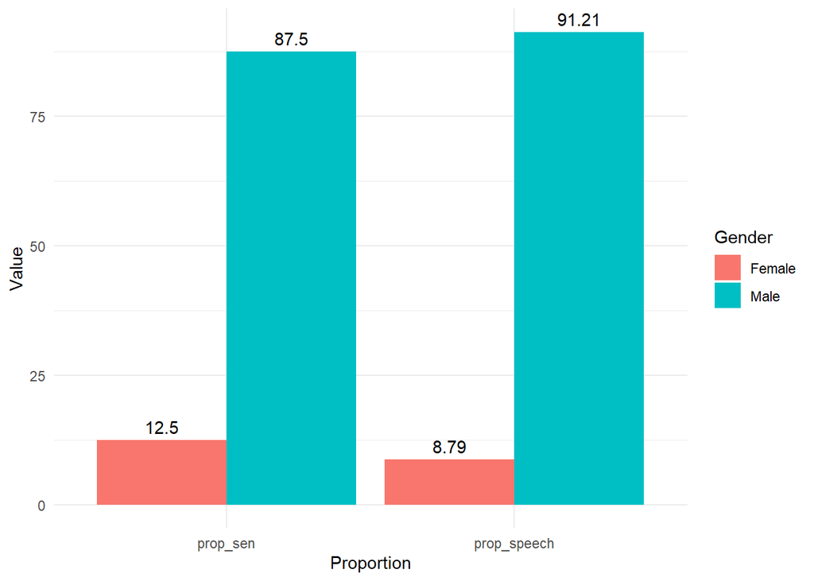

```r
# Expected frequency of speeches per gender -- based on the number of  senators
expected <-  sen_df %>%
  group_by(gender) %>%
  summarise(n = n()) %>%
  mutate(prop = (n / sum(n))*100) %>%
  rename(n_sen = n, prop_sen = prop, Gender = gender)

# Observed frequency of speeches
observed <- speech_df  %>%
  group_by(Gender) %>%
  summarise(n = n()) %>%
  mutate(prop = (n / sum(n))*100) %>%
  rename(n_speech = n, prop_speech = prop)

merge(expected, observed, by = 'Gender') %>%
  select(Gender, prop_sen, prop_speech) %>%
  pivot_longer(!Gender, names_to = 'Proportion', values_to = 'Value') %>%
  mutate(across(is.numeric, ~ round(., 2))) %>%
  ggplot(aes(Value, Proportion, group = Gender, fill = Gender)) +
  geom_col(position = 'dodge') +
  geom_text(aes(label = Value), position = position_dodge(0.9),
            show.legend = FALSE, vjust = -0.5) +
  coord_flip() +
  theme_minimal()
```

### Parties

In what concerns the distribution of speeches per party, we expected MDB, PODEMOS, and PSD to have a higher number of speeches, as they account for a larger percentage of the Senate House.

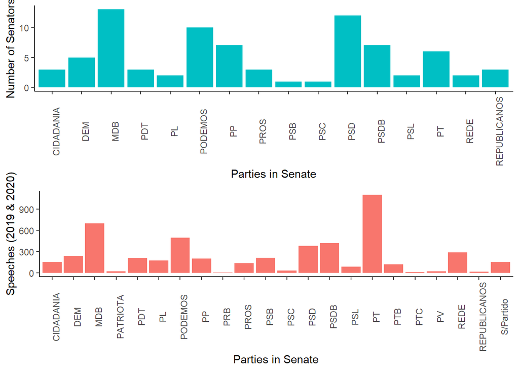

```r
# Plot senators by party
party_sen <- sen_df %>%
  group_by(party_abbr) %>%
  summarise(n = n()) %>%
  ggplot(aes(party_abbr, n)) +
  geom_col(fill = '#00BFC4') +
  ylab('Number of Senators') +
  xlab('Parties in Senate') +
  theme_classic() +
  theme(axis.text.x = element_text(angle = 90))

# Plot speeches by party
party_speech <- speech_df %>%
  group_by(Partido) %>%
  summarise(n = n()) %>%
  ggplot(aes(Partido, n)) +
  geom_col(fill = '#F8766D') +
  ylab('Speeches (2019 & 2020)') +
  xlab('Parties in Senate') +
  theme_classic() +
  theme(axis.text.x = element_text(angle = 90))

gridExtra::grid.arrange(party_sen, party_speech)
```

In the graph below, parties represented in blue have spoken more than their expected average, considering their number of senators. Parties represented in red have spoken less than their expected average. This finding suggests that parties from the left, noticeably, PT and REDE, speak more than their peers. This might lead to a higher opposition to Bolsonaro’s agenda within the Senate.

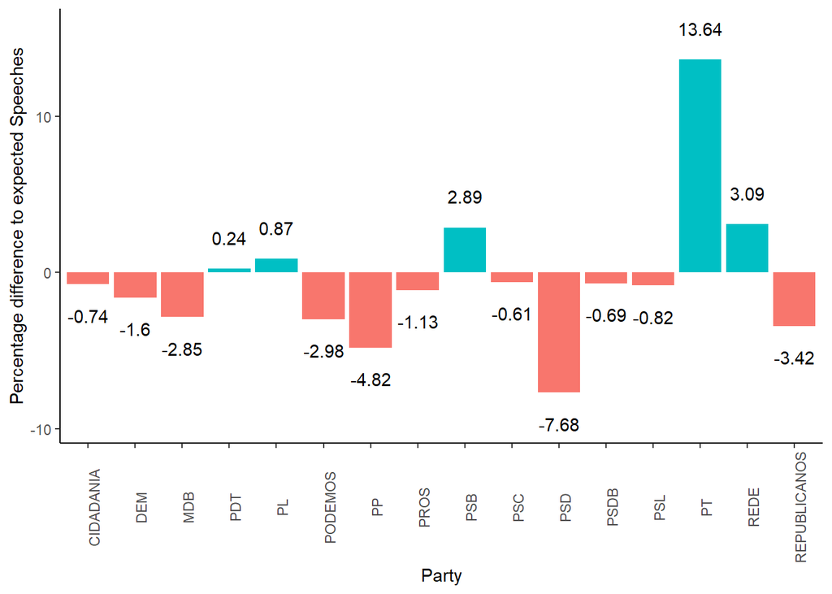

```r
# Number of speeches
n_speeches <- speech_df %>%
  group_by(Partido) %>%
  summarise(Speeches = n()) %>%
  mutate(Prop_Speeches = round((Speeches / sum(Speeches))*100, 2))

# Number of senators/total
n_senators <- sen_df %>%
  rename(Partido = 'party_abbr') %>%
  group_by(Partido) %>%
  summarise(Senators = n()) %>%
  mutate(Prop_Senators = (Senators / sum(Senators))*100)

# Plot
merge(n_speeches, n_senators, by = 'Partido') %>%
  select(Partido, Prop_Senators, Prop_Speeches) %>%
  arrange(desc(Prop_Speeches)) %>%
  mutate(diff = Prop_Speeches - Prop_Senators) %>%
  group_by(Partido) %>%
  ggplot(aes(Partido, diff, label = diff, fill = ifelse(diff < 0, '#00BFC4', '#F8766D'))) +
  geom_col() +
  geom_text(aes(y = diff + 2 * sign(diff), label = diff), position = position_dodge(width = 0.9)) +
  ylab('Percentage difference to expected Speeches') +
  xlab('Party') +
  theme_classic() +
  theme(axis.text.x = element_text(angle = 90), legend.position = 'none')
```

One final thing needs to be mentioned about Brazilian politics current state of affairs. In recent years, politicians in Brazil have often changed parties. This happens mostly out of ideological differences and conflicts with party leadership. In fact, Bolsonaro has been partyless (‘S/ Partido’) for over a year.

The lack of party loyalty and identification that is currently a trend in the Brazilian political context might render any study that attempts to draw an inference about party positions from politicians’ speeches susceptible to criticism. Katia Abreu, for instance, has been associated with 3 different parties in the period of 2019-2020, and has also been partyless for a while. In order to assess the degree to which this study is vulnerable to this criticism, we listed bellow the changes in party affiliation that affect our corpus.

```r
# Party Changes
change <- speech_df %>%
  group_by(Nome, Partido) %>%
  count()

# Create List
list_change <- change %>%
  group_by(Nome) %>%
  count() %>%
  filter(n > 1) %>%
  pull(Nome)

# Subset
final_change <- change %>%
  subset(Nome %in% list_change) %>%
  select(Nome, Partido)

# Print
final_change
```

| Nome | Partido |
| --- | --- |
| Alvaro Dias | PODEMOS |
| Alvaro Dias | PV |
| Antonio Anastasia | PSD |
| Antonio Anastasia | PSDB |
| Eduardo Girao | PODEMOS |
| Eduardo Girao | PROS |
| Elmano Ferrer | MDB |
| Elmano Ferrer | PODEMOS |
| Fernando Bezerra Coelho | MDB |
| Fernando Bezerra Coelho | PSB |
| Fernando Collor | PROS |
| Fernando Collor | PTC |
| Jorge Kajuru | CIDADANIA |
| Jorge Kajuru | PATRIOTA |
| Jorge Kajuru | PSB |
| Katia Abreu | MDB |
| Katia Abreu | PDT |
| Katia Abreu | PP |
| Katia Abreu | S/Partido |
| Lasier Martins | PODEMOS |
| Lasier Martins | PSD |
| Marcos do Val | CIDADANIA |
| Marcos do Val | PODEMOS |
| Mecias de Jesus | PRB |
| Mecias de Jesus | REPUBLICANOS |
| Reguffe | PODEMOS |
| Reguffe | S/Partido |
| Roberto Rocha | PSB |
| Roberto Rocha | PSDB |
| Romario | PODEMOS |
| Romario | PSB |
| Rose de Freitas | MDB |
| Rose de Freitas | PODEMOS |
| Telmario Mota | PROS |
| Telmario Mota | PTB |
| Vanderlan Cardoso | PP |
| Vanderlan Cardoso | PSD |

### States

Our data set is composed of 5188 speeches given by 80 senators from 27 states. Assuming each senator uses speaking opportunities equally, we would expect each state to have around 192 speeches. What we see is that senators coming from some states, such as RS, PE, DF, and AP far exceed the expected average of speeches; at the same time, senators from PB, AC, and RJ seem not to have spoken as much as their peers in 2019 and 2020.

This might indicate that the items relevant for the agenda of the states that have more speeches might bear higher weight in the corpus.

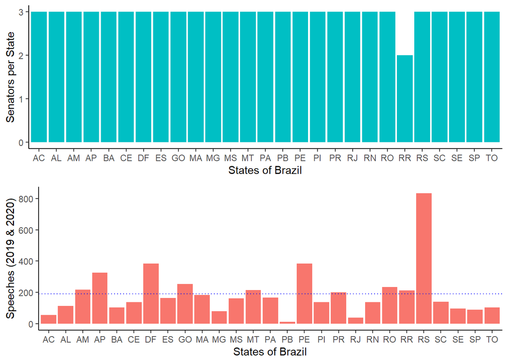

```r
# Plot senators by state
state_sen <- sen_df %>%
  group_by(state) %>%
  summarise(n = n()) %>%
  ggplot(aes(state, n)) +
  geom_col(fill = '#00BFC4') +
  ylab('Senators per State') +
  xlab('States of Brazil') +
  theme_classic()

# Plot speeches by state
state_speech <- speech_df %>%
  group_by(UfParlamentarNaData) %>%
  summarise(n = n()) %>%
  ggplot(aes(UfParlamentarNaData, n)) +
  geom_col(fill = '#F8766D') +
  geom_hline(yintercept = 192, linetype = 'dotted', col = 'blue') +
  ylab('Speeches (2019 & 2020)') +
  xlab('States of Brazil') +
  theme_classic()

gridExtra::grid.arrange(state_sen, state_speech)
```

## Speeches Scaling

First, we use *Wordfish* as the text scaling method for the Senate speeches. After, as shown below, we plot the results of a fitted scaling model. The plot shows PL as the party farthest to the right and PT as the one farthest to the left.

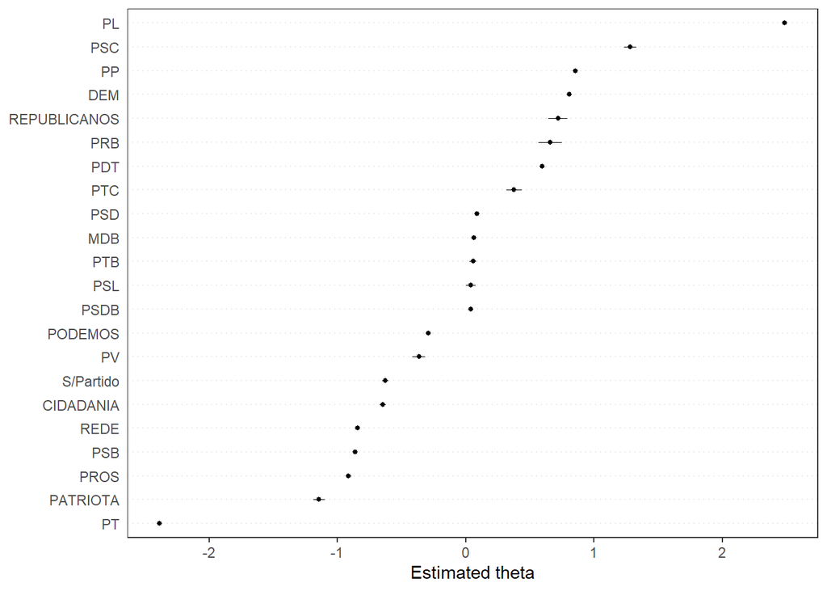

```r
# Main Senate Corpus
corp_sen <- corpus(speech_df, docid_field = 'CodigoPronunciamento',
                   text_field = 'Pronunciamento')

# Main Senate DFM
dfmat_sen <- dfm(corp_sen,
  tolower = TRUE,
  remove_punct = TRUE,
  remove = stopwords('portuguese'),
  remove_numbers = TRUE,
  remove_separators = TRUE,
  remove_symbols = TRUE,
  stem = FALSE,
  groups = 'Partido')

dfmat_sen <- dfm_select(dfmat_sen, min_nchar = 2)
docnames(dfmat_sen) <- paste(dfmat_sen$Partido)

# Wordfish
wf <- textmodel_wordfish(dfmat_sen, dir = c(16, 6), sparse = TRUE) # PT and PL
textplot_scale1d(wf)
```

### Wordfish Scores X Media

To better understand the Senate speeches positions generated with *Wordfish*, we compare them with the media perception of each party.

#### Wordfish vs Media assessment

The graph below shows a press assessment - *Congresso em Foco* - (y-axis) and the *Wordfish* categorization (x-axis) for each party.

Some parties appear in similar positions in both situations, such as PSB, PSDB, and MDB. On the other hand, the *Wordfish* model considers PT to be in the extreme left, around -2 on the scale. In contrast, the media categorization considers the same party in the left, at -1 on the scale.

We see the same pattern on the other side of the scale. While the media puts PSL in the right, the *Wordfish* model assumes the same party is located in the center.

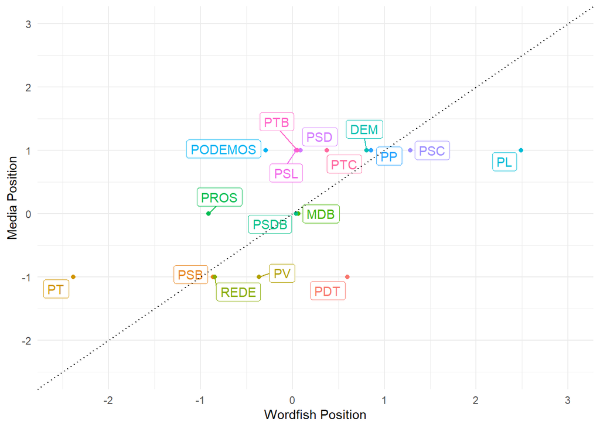

```r
# Code right, left, center positions
cemf_2019 <-  cemf_2019 %>%
  mutate(score = if_else(pos == 'centro', 0, if_else(pos == 'esquerda', -1, 1)))

# Data frame with Wordsfish party positions from Senate speeches
theta_sen_wf <- as.data.frame(wf$theta, wf$docs) %>%
    rownames_to_column('party') %>%
    rename(theta_sen_wf = 'wf$theta')

# Merge
scores <- merge(theta_sen_wf, cemf_2019, by = 'party')

#Plot
scores %>%
  arrange(score) %>%
  mutate(party = factor(party, levels = party)) %>%
  ggplot(aes(x = theta_sen_wf, y = score, label = party, col = party)) +
  geom_point() +
  geom_label_repel(show.legend = FALSE) +
  geom_abline(linetype = 'dotted') +
  xlim(-2.5, 3) +
  ylim(-2.5, 3) +
  ylab('Media Position') +
  xlab('Wordfish Position') +
  theme_minimal() +
  theme(legend.position = 'none')
```

#### Weighted by Number of Senators

This graph displays parties’ positions (*Wordfish* x Media), with circle sizes representing the weight of the party in the Senate House in terms of number of senators. This represents parties’ relative importance in approving laws, as number of senators directly affect the number of votes.

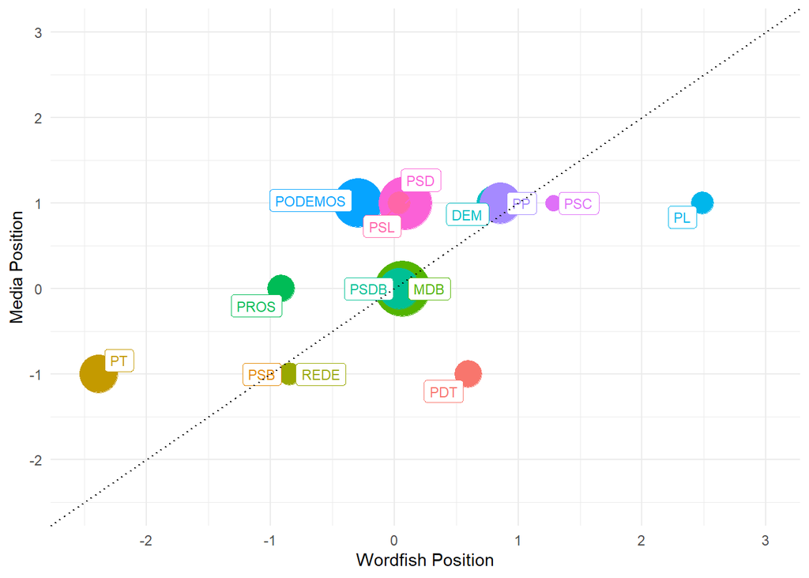

```r
# Plot with media position and number of senators
sen_df %>%
  group_by(party_abbr) %>%
  summarise(n = n()) %>%
  rename(party = 'party_abbr') %>%
  merge(scores, by = 'party') %>%
  arrange(score) %>%
  mutate(party = factor(party, levels = party)) %>%
  ggplot(aes(x = theta_sen_wf, y = score, size = n, color = party)) +
  geom_point() +
  geom_label_repel(aes(label = party), size = 3) +
  scale_size_area(max_size = 16) +
  geom_abline(linetype = 'dotted') +
  xlim(-2.5, 3) +
  ylim(-2.5, 3) +
  ylab('Media Position') +
  xlab('Wordfish Position') +
  theme_minimal() +
  theme(legend.position = 'none')
```

#### Weighted by Number of Speeches

This graph displays parties positions (*Wordfish* x Media), with circle sizes representing the weight of the party in the Senate in terms of number of speeches. This represents parties’ relative importance in affecting our corpus composition. Assuming senators can change their mind by listening to their peers, this could also be a measure of their reach.

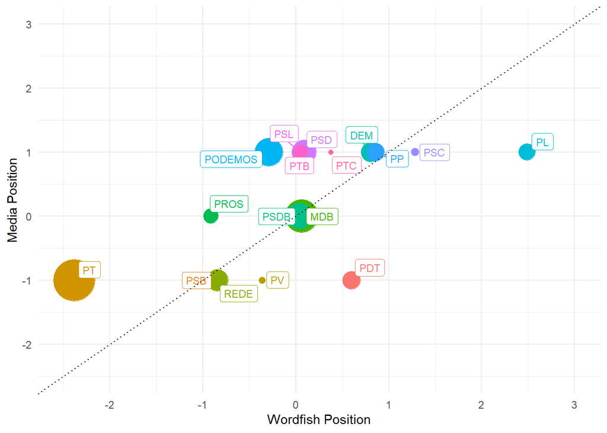

```r
# Plot media position and number of speeches
speech_df %>%
  group_by(Partido) %>%
  summarise(n = n()) %>%
  rename(party = 'Partido') %>%
  merge(scores, by = 'party') %>%
  arrange(score) %>%
  mutate(party = factor(party, levels = party)) %>%
  ggplot(aes(x = theta_sen_wf, y = score, size = n, color = party)) +
  geom_point() +
  geom_label_repel(aes(label = party), size = 3) +
  scale_size_area(max_size = 16) +
  geom_abline(linetype = 'dotted') +
  xlim(-2.5, 3) +
  ylim(-2.5, 3) +
  ylab('Media Position') +
  xlab('Wordfish Position') +
  theme_minimal() +
  theme(legend.position = 'none')
```

### 2018’s Presidential Manifestos

In this section, we use *Austin* to estimate party positions from presidential manifestos for the 2018 election.

```r
# Corpus presidential speeches
corp_pres <- corpus(pres_df, docid_field = 'party',
                   text_field = 'text')

# DFM
dfmat_pres <- dfm(corp_pres,
  tolower = TRUE,
  remove_punct = TRUE,
  remove = stopwords('portuguese'),
  remove_numbers = TRUE,
  remove_separators = TRUE,
  remove_symbols = TRUE,
  stem = FALSE)

dfmat_pres <- dfm_select(dfmat_pres, min_nchar = 2)
```

#### Austin Prediction

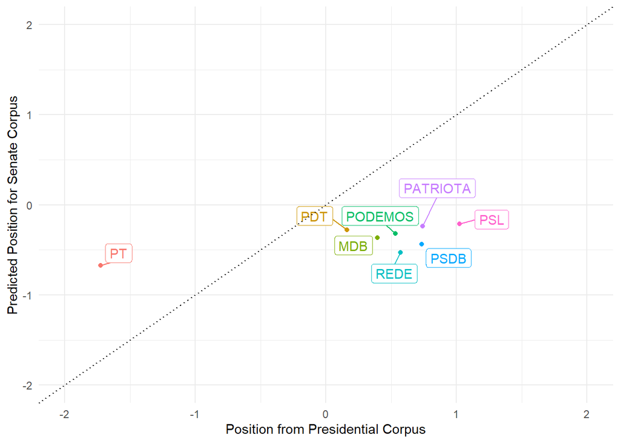

```r
# Austin
# Convert to WFM
wfm_pres <- as.wfm(dfmat_pres, word.margin = 2)

# Wordfish pres
wfa_pres <- wordfish(wfm_pres, dir = c(4, 3)) # PSOL, PSL

# pres scores
theta_pres_au <- as.data.frame(wfa_pres$theta, wfa_pres$docs) %>%
  rownames_to_column('party') %>%
  rename(theta_pres = 'wfa_pres$theta')

# Match sen features with pres
dfmat_sen_match <- dfm_match(dfmat_sen, featnames(dfmat_pres))

# Convert to WFM
wfm_sen <- as.wfm(dfmat_sen_match, word.margin = 2)

# Out of sample Austin prediction to senate speeches
theta_sen_au <- as.data.frame(predict(wfa_pres, newdata = wfm_sen)) %>%
  rownames_to_column('party') %>%
  rename(theta_sen_au = 'predict(wfa_pres, newdata = wfm_sen)')

# merge dfs -- theta pres and sen
theta_ps <- merge(theta_pres_au, theta_sen_au, by = 'party')

# Compare pres x sen
theta_ps %>%
  arrange(theta_pres) %>%
  mutate(party = factor(party, levels = party)) %>%
  ggplot(aes(x = theta_pres, y = theta_sen_au, label = party, col = party)) +
  geom_point() +
  geom_label_repel(show.legend = FALSE) +
  geom_abline(linetype = 'dotted') +
  xlim(-2, 2) +
  ylim(-2, 2) +
  ylab('Predicted Position for Senate Corpus') +
  xlab('Position from Presidential Corpus') +
  theme_minimal() +
  theme(legend.position = 'none')
```

#### Austin vs. Wordfish

The graph shows party positions derived from Senate speeches. The y-axis contains values from *Austin’s* out-of-sample prediction from presidential manifestos and the x-axis contains *Wordfish* values. We see that *Austin* predictions are more centered, while *Wordfish* are more polarized.

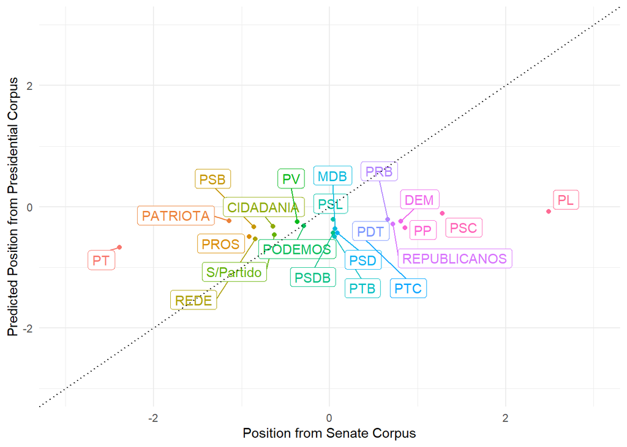

```r
# Compare wf_sen x out of sample Austin prediction to senate speeches
merge(theta_sen_wf, theta_sen_au, by = 'party') %>%
  arrange(theta_sen_wf) %>%
  mutate(party = factor(party, levels = party)) %>%
  ggplot(aes(x = theta_sen_wf, y = theta_sen_au, label = party, col = party)) +
  geom_point() +
  geom_label_repel(show.legend = FALSE) +
  geom_abline(linetype = 'dotted') +
  xlim(-3, 3) +
  ylim(-3, 3) +
  ylab('Predicted Position from Presidential Corpus') +
  xlab('Position from Senate Corpus') +
  theme_minimal() +
  theme(legend.position = 'none')
```

# Themes

Having assessed how the parties in the Senate are positioned in the RILE scale, let’s check how the discussions on the three topics of Bolsonaro’s agenda appear in the Senate.

For this section, we employed a dictionary analysis, identifying a few words with each topic to classify the corpus accordingly.

We initially consulted the “LexiCoder Policy Agenda” dictionary to have a baseline for words that could capture these main topics. We then translated the words into Portuguese and adapted them for the Brazilian context.

In the following sections, we will analyze the three aforementioned dimensions under the topics Economy, Security, and Gender & Family.

To extract documents for each topic, we filtered texts that have higher scores in a determined topic when compared to the others.

```r
# Create Dictionary with themes of interest
theme.lexicon <- dictionary(list(economy = c('econom*', 'desempreg*', 'inflação', 'demanda', 'oferta', 'negócios', 'empreg*', 'preço*', 'banco', 'dinheiro', 'gastos', 'dívida', 'juro*', 'control*', 'custo*', 'produtividade', 'índice', 'renda', 'pib', 'produto', 'bruto', 'empreg*', 'trabalh*', 'privat*', 'auxílio', 'desigualdade', 'petróleo', 'petro', 'desigual*', 'custo*', 'capital', 'ações', 'participação', 'aposent*', 'nacionalizar', 'mercado'), genfam = c('famíl*', 'famil*', 'just*', 'mulher*', 'solteir*', 'sex*', 'pai*', 'mãe', 'filh*', 'abort*', 'criança*', 'abrigo', 'gênero', 'gay', 'kit gay', 'jove*', 'juventude', 'tradicional'), security = c('sequestr*', 'inocent*', 'puni*','condena*','sentença', 'tribunal', 'juiz', 'justiça', 'crim*', 'bandid*', 'criminos*', 'ilícit*', 'infrator*', 'impunidade', 'promotor*', 'instância', 'transitado', 'julgado', 'julgamento', 'bala', 'balead*', 'tiro', 'fuzil', 'arma', 'armamento', 'pistola', 'rifle', 'polícia', 'policial', 'militar', 'cidadão de bem', 'cadeia*', 'prisão', 'prisioneir*', 'investigação', 'intervenção militar', 'UPP', 'segurança pública', '*anticrime', '*anti-crime', 'assassin*', 'ladrão', 'vagabund*', 'saidão', 'condicional', 'progressão de regime', 'réu', 'defensoria', 'estupr*', 'traficante*', 'detenção', 'detent*',  'violência', 'reinci*', 'delinquente', 'menor', 'maioridade penal', 'drogas', 'entorpecent*')))

# Create DFM with theme.lexicon, apply weights and convert to data frame
theme_df  <- dfm(corp_sen, dictionary = theme.lexicon) %>%
    dfm_weight(scheme = 'prop') %>%
    convert('data.frame')
```

## Economy

```r
# List with documents about economy
econ_id <- theme_df %>%
  filter(economy > genfam & economy > security) %>%
  pull(doc_id)

# DFM with econ documents
dfmat_econ <- speech_df %>%
  subset(CodigoPronunciamento %in% econ_id) %>%
  corpus(docid_field = 'CodigoPronunciamento', text_field = 'Pronunciamento') %>%
  dfm(tolower = TRUE,
      remove_punct = TRUE,
      remove = stopwords('portuguese'),
      remove_numbers = TRUE,
      remove_separators = TRUE,
      remove_symbols = TRUE,
      stem = FALSE,
      groups = 'Partido')

dfmat_econ <- dfm_select(dfmat_econ, min_nchar = 2)
```

### Scaling

Comparing the economy graph for *Wordfish* with the main graph, we do not see much difference in party positions. This might suggest that discussions on the economy are the main driver behind the allocation of parties in the RILE spectrum. In other words, views on economic matters could bear a high weight in the definition of where a party is positioned in the ideological spectrum. This suggests that economic discussions are more salient in the corpus.

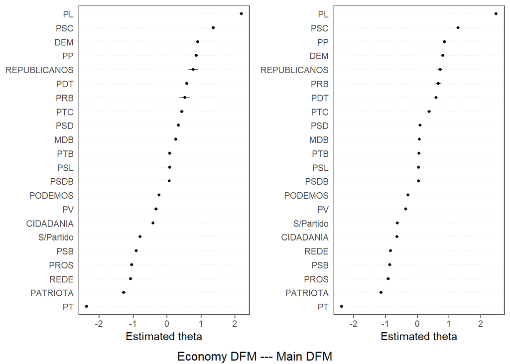

```r
# Wordfish for economy DFM
wf_econ <- textmodel_wordfish(dfmat_econ, dir = c(16, 6), sparse = TRUE) # PT and PR


# Plot economy and main DFM graphs
gridExtra::grid.arrange(textplot_scale1d(wf_econ), textplot_scale1d(wf), ncol = 2,
                        bottom = 'Economy DFM --- Main DFM')
```

### RILE Features

The graph displays words that push a document farthest to the left or the right. Words located at the bottom are used less frequently. Right and left word positions (beta) range from approximately -2.5 to 2.

The words that most contributed for a left-leaning document are *petrobrás* (an oil extracting public company whose privatization is a contentious topic), *anticapitalista* (‘anticapitalist’), *cut* (‘centralized labour union’), *auxílio-doença* (‘illness aid’, an employment benefit), *sindicalista* (‘unionist’) and *terceirização* (‘outsourcing’).

For the right, the words are *militarismo* (‘militarism’), *agroindustriais* (‘agribusiness’), *grevista* (‘striker’), *veterinária* (‘veterinarian’), *logística* (‘logistics’) and *transportes* (‘transport’).

In general, the right discusses business, agriculture, and themes related to a somewhat liberal agenda (with words like entrepreneurship, liberalism, and infrastructure). The left discusses pension benefits, worker’s rights, and trade unionism.

Both sides talk about macroeconomic policies, with words like inflation, GDP, debt, and spending.

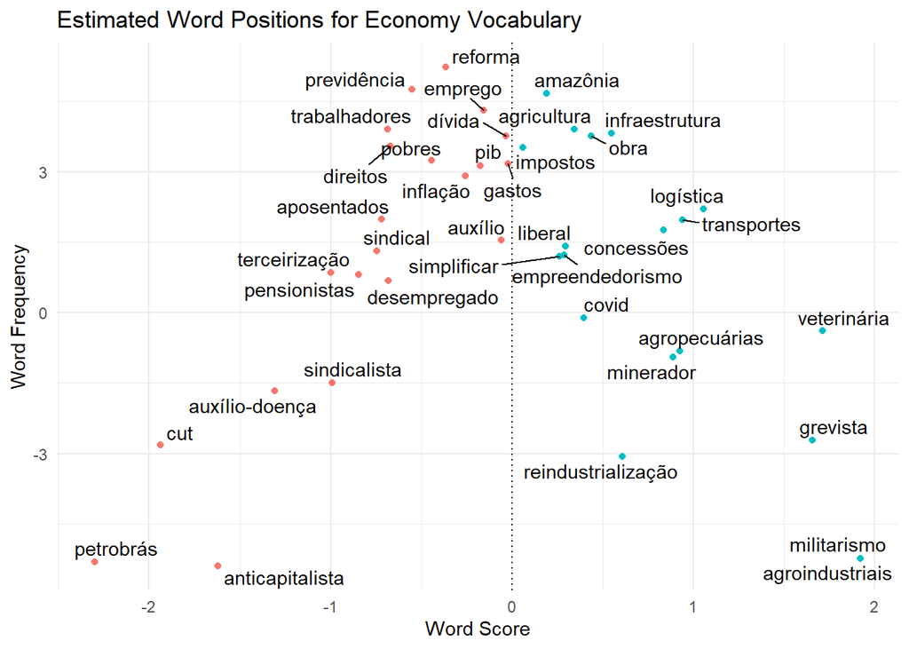

```r
# Features usage left/right
feat_econ <- data.frame(
  word = wf_econ$features,
  beta = wf_econ$beta,
  psi = wf_econ$psi,
  stringsAsFactors = FALSE)

# Select words for graph
words_econ <- c('trabalhadores', 'direitos', 'aposentados', 'pensionistas', 'escrvavidão', 'liberal',
                'petrobrás', 'auxílio', 'previdência', 'covid', 'desempregado', 'sindical',
                'amazônia', 'terceirização', 'agroindustriais', 'militarismo', 'grevista','emprego',
                'veterinária', 'agropecuárias', 'pib', 'dívida', 'impostos', 'gastos', 'minerador',
                'concessões', 'logística', 'transportes', 'obra', 'anticapitalista','inflação',
                'infraestrutura', 'pobres', 'reforma', 'agricultura', 'auxílio-doença',
                'sindicalista', 'cut', 'reindustrialização','simplificar', 'empreendedorismo')

# Extract scores
scores_econ <- arrange(filter(feat_econ, word %in% words_econ), beta)

# Plot words on the RILE scale
ggplot(scores_econ, aes(beta, psi, label = word)) +
  geom_point(data = scores_econ, color = ifelse(scores_econ$beta > 0, '#00BFC4', '#F8766D')) +
  geom_text_repel(data = scores_econ, col = 'black') +
  labs(x = 'Word Score', y = 'Word Frequency') +
  ggtitle('Estimated Word Positions for Economy Vocabulary') +
  geom_vline(xintercept = c(0,0), linetype = 'dotted') +
  theme_minimal()
```

## Security

```r
# List with documents about security
sec_id <- theme_df %>%
  filter(security > genfam & security > economy) %>%
  pull(doc_id)

# DFM with sec documents
dfmat_sec <- speech_df %>%
  subset(CodigoPronunciamento %in% sec_id) %>%
  corpus(docid_field = 'CodigoPronunciamento', text_field = 'Pronunciamento') %>%
  dfm(tolower = TRUE,
      remove_punct = TRUE,
      remove = stopwords('portuguese'),
      remove_numbers = TRUE,
      remove_separators = TRUE,
      remove_symbols = TRUE,
      stem = FALSE,
      groups = 'Partido')

dfmat_sec <- dfm_select(dfmat_sec, min_nchar = 2)
```

### Scaling

Comparing the security graph for *Wordfish* with the main graph, we see a lot of change in party positions. This may suggest that security bears a smaller weight into defining general parties’ positions, and/or that there is a lot of overlap in the security vocabulary used by senators across the spectrum.

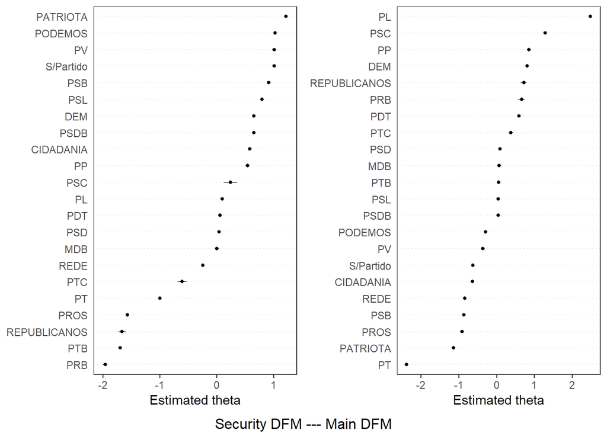

```r
# Wordfish for security DFM
wf_sec <- textmodel_wordfish(dfmat_sec, dir = c(16, 6), sparse = TRUE) # PT and PL

# Plot security and main DFM graphs
gridExtra::grid.arrange(textplot_scale1d(wf_sec), textplot_scale1d(wf), ncol = 2,
                        bottom = 'Security DFM --- Main DFM')
```

### RILE Features

The graph displays words that push a document farthest to the left or the right. Words located at the bottom are used less frequently. Right and left word positions range from approximately -1.5 to 2.0.

The words that most contributed for a left-leaning document are *defensoria* (‘public attorney office’), *defensores* (either ‘public attorneys’, or ‘defenders’), *direitos* (‘rights’), humanos (‘human’), *perseguição* (‘harassment’), *liberdade* (‘freedom’) . For the right, the words are *vagabundo(s)* (‘tramps’), *juvenis* (‘juvenile’), *tropa* (‘troop’), *pcc* (the largest gang in SP) and *feminicídio* (‘feminicide’).

In general, the right discusses crime, criminals, and law enforcement activities, while the left discusses human rights and judicial harassment.

Interestingly, the use of *cadeia* (‘jail’) and *prisão* (‘prison’), which are synonyms in Portuguese, seems associated with speeches on different sides of the RILE spectrum. Similarly, the word *vagabundagem* (idleness that characterizes a tramp) and *vagabundo(s)* (‘tramp’) are also associated with different sides of RILE.

Finally, *feminicídio* (a relatively new criminal offense for an aggravated homicide committed against a woman by her former romantic partner), which is a differentiation to standard homicide typically criticized by right-wing politicians with a conservative view of gender issues, is the word that appears most strongly associated with a right-leaning political view.

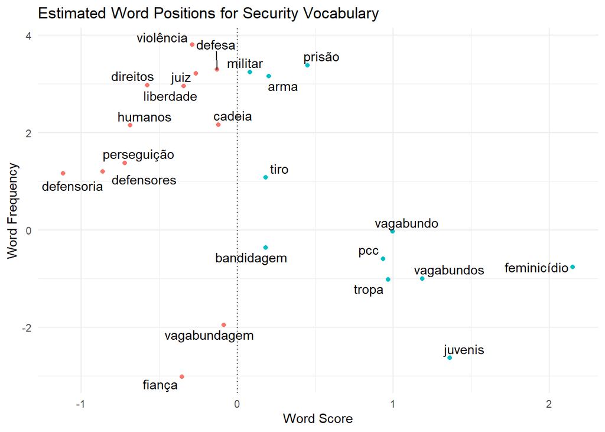

```r
# Features usage left/right
feat_sec <- data.frame(
  word = wf_sec$features,
  beta = wf_sec$beta,
  psi = wf_sec$psi,
  stringsAsFactors = FALSE)

# Select words for graph
words_sec <- c('bandidagem','direitos', 'humanos','juiz','perseguição', 'liberdade',
               'defesa','violência','cadeia', 'prisão', 'vagabundo', 'vagabundos', 'vagabundagem',
               'juvenis','arma', 'tiro', 'defensoria', 'defensores','pcc', 'tropa','feminicídio', 'fiança','militar')

# Extract scores
scores_sec <- arrange(filter(feat_sec, word %in% words_sec), beta)

# Plot words on the RILE scale
ggplot(scores_sec, aes(beta, psi, label = word)) +
  geom_point(color = ifelse(scores_sec$beta > 0, '#00BFC4', '#F8766D')) +
  geom_text_repel(data = scores_sec, col = 'black') +
  labs(x = 'Word Score', y = 'Word Frequency') +
  ggtitle('Estimated Word Positions for Security Vocabulary') +
  geom_vline(xintercept = c(0,0), linetype = 'dotted') +
  theme_minimal()
```

## Gender & Family

```r
# List with documents about gender and family
genfam_id <- theme_df %>%
  filter(genfam > security & genfam > economy) %>%
  pull(doc_id)

# DFM with genfam documents
dfmat_genfam <- speech_df %>%
  subset(CodigoPronunciamento %in% genfam_id) %>%
  corpus(docid_field = 'CodigoPronunciamento', text_field = 'Pronunciamento') %>%
  dfm(tolower = TRUE,
      remove_punct = TRUE,
      remove = stopwords('portuguese'),
      remove_numbers = TRUE,
      remove_separators = TRUE,
      remove_symbols = TRUE,
      stem = FALSE,
      groups = 'Partido')

dfmat_genfam <- dfm_trim(dfmat_genfam, min_termfreq = 2, min_docfreq = 2)
```

### Scaling

Comparing the gender and family graph for *Wordfish* with the main graph, we see some change in party positions. PT is considered extreme left in the main DFM, while left in the gender & family DFM. Topics included in gender and family might not be drivers behind the allocation of parties in the RILE spectrum. Furthermore, this suggests that gender & family bears a smaller weight into defining general parties’ positions, and/or there is a lot of overlap in the gender & family vocabulary used by senators across the spectrum.

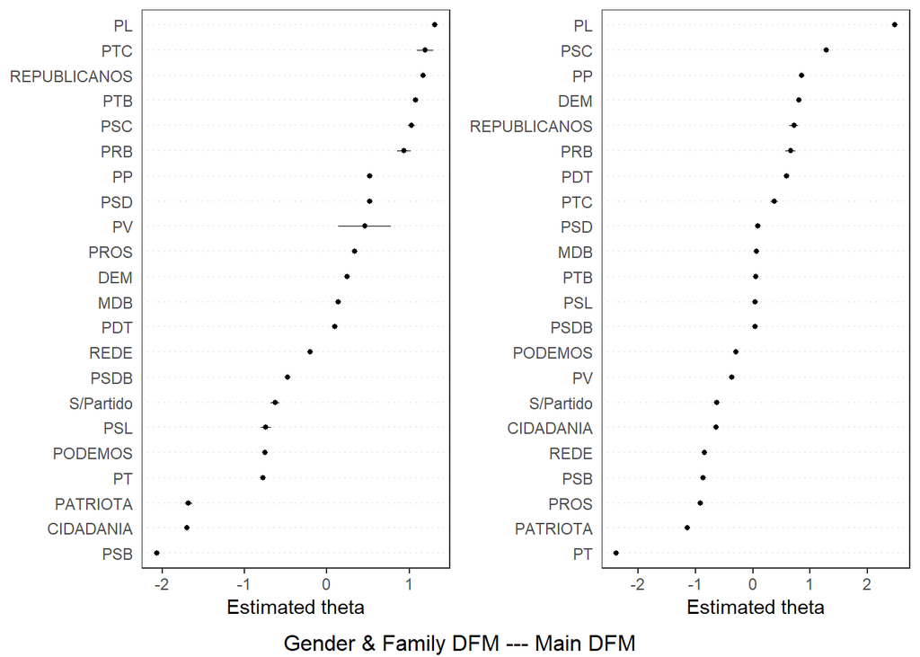

```r
# Wordfish for gender and family DFM
wf_genfam <- textmodel_wordfish(dfmat_genfam, dir = c(16, 6), sparse = TRUE) # PT and PL

# Plot gender & family and main DFM graphs
gridExtra::grid.arrange(textplot_scale1d(wf_genfam), textplot_scale1d(wf), ncol = 2,
                        bottom = 'Gender & Family DFM --- Main DFM')
```

### RILE Features

The graph displays words that push a document farthest to the left or the right. Words located at the bottom are used less frequently. Right and left word positions range from approximately -0.5 to 0.5.

The word that most contributes to a left-leaning document is *resistência* (‘resistance’). The words that most contribute to a right-leaning document are *tradicional* (‘traditional’) and *esposa* (‘wife’). All the other words are close to the center.

Finally, words that we expected to be highly significant don’t even appear in speeches. Some examples are *sexista* (‘sexist’) and *gay*.

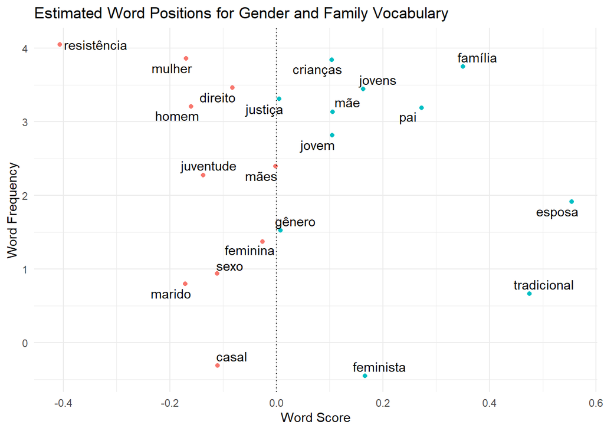

```r
# Features usage left/right
feat_genfam <- data.frame(
  word = wf_genfam$features,
  beta = wf_genfam$beta,
  psi = wf_genfam$psi,
  stringsAsFactors = FALSE)

# Select words for graph
words_genfam <- c('tradicional', 'mulher', 'gênero', 'sexo', 'homem', 'feminista', 'juventude',
                  'jovem', 'jovens', 'família', 'resistência', 'direito', 'crianças', 'mãe', 'mães',
                  'pai', 'justiça', 'feminina', 'marido', 'esposa', 'casal')

#Extract scores
scores_genfam <- arrange(filter(feat_genfam, word %in% words_genfam), beta)

# Plot words on the RILE scale
ggplot(scores_genfam, aes(beta, psi, label = word)) +
  geom_point(color = ifelse(scores_genfam$beta > 0, '#00BFC4', '#F8766D')) +
  geom_text_repel(data = scores_genfam, col = 'black') +
  labs(x = 'Word Score', y = 'Word Frequency') +
  ggtitle('Estimated Word Positions for Gender and Family Vocabulary') + geom_vline(xintercept =
          c(0,0), linetype = 'dotted') +
  theme_minimal()
```

# Conclusion

From our analysis, we infer that not all themes present in Bolsonaro’s discourse have the same relevance in the speeches of the Brazilian Senate.

Economy bears a higher weight in the discussions in the Senate, and better reflects the partisan division between those on the left that advocate for a heterodox approach, with state driving investment, and those on the right, that tend to favor an orthodox approach, advocating for liberal policies. Security and Gender & Family seem less salient in the discussions of the Senate, and there seems to be a bigger overlap in the use of vocabulary by parties from different sides of the spectrum.

While Bolsonaro’s agenda is certainly contentious in Brazilian society, making for daily headlines in the Brazilian press, the Senate doesn’t seem to give the same weight to discussing his proposals for Security and Gender & Family as we would have expected just from reading the newspapers.

On the other hand, a prevalence of speeches from the opposition may explain, at least in part, the lack of resonance of Bolsonaro’s project in the Senate. Take PT as an example; it is one of the main opposition parties to Bolsonaro and has a large participation in overall Senate speeches.

# References

Alexandrova, P. (2019). The EU Policy Agendas Project. Comparative Policy Agendas, 191-199. doi:10.1093/oso/9780198835332.003.0022

Benoit, K., Watanabe, K., Wang, H., Nulty, P., Obeng, A., Müller, S., & Matsuo, A. (2018). Quanteda: An R package for the quantitative analysis of textual data. Journal of Open Source Software, 3(30), 774. doi:10.21105/joss.00774

Egerod, B. C., & Klemmensen, R. (2020). Scaling Political Positions from Text: Assumptions, Methods and Pitfalls. The SAGE Handbook of Research Methods in Political Science and International Relations, 498-521. doi:10.4135/9781526486387.n30

Laver, M., Benoit, K., & Garry, J. (2003). Extracting Policy Positions from Political Texts Using Words as Data. American Political Science Review, 97(02). doi:10.1017/s0003055403000698

Lowe, W. (2017). Austin: Do things with words. http://conjugateprior.github.io/austin.

Traber, D. MZES Social Science Data Lab. (2019, July 22). Quantitative Analysis of Political Text. Retrieved from https://www.mzes.uni-mannheim.de/socialsciencedatalab/article/quantitative-analysis-of-political-text/

# Note on Contributions

We cooperated both in code development and in analysis, and contributed to discussing which analysis we should apply (and which we should drop) as a group. Carol handled the economy analysis, Ana the security analysis and Stefania the gender & family analysis.

[^1]: https://www.tse.jus.br/imprensa/noticias-tse/2018/Setembro/tse-indefere-pedido-de-registro-de-candidatura-de-lula-a-presidencia-da-republica
[^2]: https://pt.wikipedia.org/wiki/Lista_de_partidos_pol%C3%ADticos_do_Brasil
[^3]: https://g1.globo.com/politica/noticia/2020/10/20/apos-pedir-afastamento-do-mandato-chico-rodrigues-amplia-licenca-de-90-para-121-dias.ghtml
[^4]: https://cnae.ibge.gov.br/en/component/content/article/95-7a12/7a12-vamos-conhecer-o-brasil/nosso-povo/16048-numero-de-homens-e-mulheres.html